# Tutorial: O-ring Failure Rates Prior to the Challenger Shuttle Loss

## Coping with missing information

In this tutorial, we will use a real data set where unwise interpretation of incomplete data had serious consequences to illustrate how such selection effects could be modeled. You will

- implement and fit a simple model for the probability of O-ring failure as a function of ambient temperature, assuming a complete data set;
- modify the model to account for censoring of the data;
- futher modify the model to account for truncation;
- ponder the differences in the conclusions in each case.

```python
# !pip install incredible pygtc

import numpy as np
import scipy.stats as st
import matplotlib.pyplot as plt
%matplotlib inline

import incredible as cr
from pygtc import plotGTC

# here are some packages you may want to use (pip install if needed)
#import dynesty
#import emcee
#import lmc
#import pymc
```

```python
# do not mess with the housekeeping
# Tests housekeeping
```

## Background

On January 28, 1986, the Space Shuttle Challenger was destroyed in an explosion during launch. The cause was eventually found to be the failure of an O-ring seal that normally prevents hot gas from leaking between two segments of the solid rocket motors during their burn. The ambient atmospheric temperature of just 36 degrees Fahrenheit, much colder than any previous launch, was determined to be a significant factor in the failure.

A relevant excerpt from the [Report of the Presidential Commission on the Space Shuttle Challenger Accident](https://history.nasa.gov/rogersrep/genindex.htm) reads:

#### Temperature Effects

> The record of the fateful series of NASA and Thiokol meetings, telephone conferences, notes, and facsimile transmissions on January 27th, the night before the launch of flight 51L, shows that only limited consideration was given to the past history of O-ring damage in terms of temperature. The managers compared as a function of temperature the flights for which thermal distress of O-rings had been observed-not the frequency of occurrence based on all flights (Figure 6). In such a comparison, there is nothing irregular in the distribution of O-ring "distress" over the spectrum of joint temperatures at launch between 53 degrees Fahrenheit and 75 degrees Fahrenheit. When the entire history of flight experience is considered, including "normal" flights with no erosion or blow-by, the comparison is substantially different (Figure 7).

> This comparison of flight history indicates that only three incidents of O-ring thermal distress occurred out of twenty flights with O-ring temperatures at 66 degrees Fahrenheit or above, whereas, all four flights with O-ring temperatures at 63 degrees Fahrenheit or below experienced O-ring thermal distress.

> Consideration of the entire launch temperature history indicates that the probability of O-ring distress is increased to almost a certainty if the temperature of the joint is less than 65.

For this notebook, we will simplify the data for each launch from integer (how many incidents of O-ring damage) to boolean (was there any damage, or not). The temperatures corresponding to "failure" (any incidents) and "success" (no incidents) are:

```python
failure_temps = np.array([53., 56., 57., 63., 70., 70., 75.])
success_temps = np.array([66., 67., 67., 67., 68., 69., 70., 70., 72., 73., 75., 76., 76., 78., 79., 80., 81.])
```

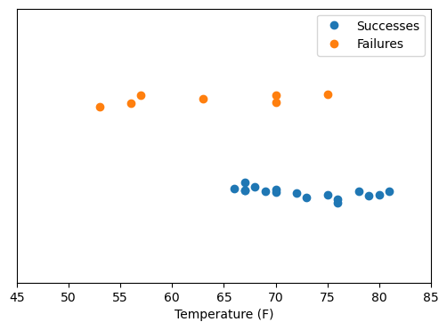

```python
plt.rcParams['figure.figsize'] = (6, 4)
plt.plot(success_temps, st.norm.rvs(success_temps*0.0, 0.05), 'o', label='Successes');
plt.plot(failure_temps, st.norm.rvs(failure_temps*0.0+1.0, 0.05), 'o', label='Failures');
plt.xlim(45,85); plt.ylim(-1,2); plt.xlabel('Temperature (F)'); plt.yticks([]); plt.legend();
```

## 1. Defining a model

Before worrying about missing data, let's define a model that we might want to fit to the complete data. We're interested in whether the probability of having zero O-ring incidents (or non-zero incidents, conversely) is a function of temperature. One possible parametrization that allows this is the [logistic function](https://en.wikipedia.org/wiki/Logistic_function), which squeezes the real line onto the range (0,1).

For reasons that may be clear later, I suggest defining the model in terms of the probability of success (zero incidents),

$P_\mathrm{success}(T|T_0,\beta,P_\mathrm{cold},P_\mathrm{hot}) = P_\mathrm{cold} + \frac{P_\mathrm{hot} - P_\mathrm{cold}}{1 + e^{-\beta(T-T_0)}}$,

with parameters $T_0$ and $\beta$ respectively determining the center and width of the logistic function, and $P_\mathrm{cold}$ and $P_\mathrm{hot}$ determine the probabilities of success at very low and high temperatures (which need not be 0 or 1).

As we'll see in a moment, a model like this provides a smooth, linear-ish transition between two extreme values, without imposing the strong prior that $P_\mathrm{success}$ *must* drop to zero at some point, for example.

As usual, it's convenient to define a standard order and naming convention for the parameters.

```python
param_names = ['T0', 'beta', 'Pcold', 'Phot']
param_labels = [r'$T_0$', r'$\beta$', r'$P_\mathrm{cold}$', r'$P_\mathrm{hot}$']
```

### 1a. Implement this function and have a look

Complete the following function to compute $P_\mathrm{success}$, as given above.

```python
def P_success(T, T0, beta, Pcold, Phot):
    """
    All arguments: scalars or equal-sized arrays
    Return value: similarly, scalar or array
    """
    # YOUR CODE HERE
    raise NotImplementedError()
```

Below we plot the function for a few different parameter values. If you've never worked with the logistic function (or a similar *sigmoid* function) before, this will give you an idea of how flexible it is and isn't.

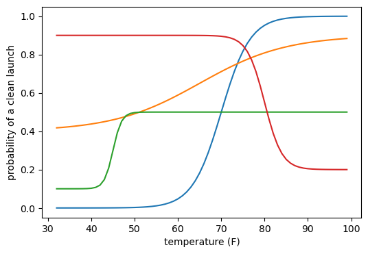

```python
plt.rcParams['figure.figsize'] = (6, 4)
T_axis = np.arange(32., 100.)
plt.plot(T_axis, P_success(T_axis, 70.0, 0.3, 0.0, 1.0));
plt.plot(T_axis, P_success(T_axis, 65.0, 0.1, 0.4, 0.9));
plt.plot(T_axis, P_success(T_axis, 45.0, 1.0, 0.1, 0.5));
plt.plot(T_axis, P_success(T_axis, 80.0, 0.5, 0.9, 0.2));
plt.xlabel('temperature (F)');
plt.ylabel('probability of a clean launch');
```

```python
# this will test your P_success function
# Tests Psuccess_test (1 point)
```

### 1b. PGM and priors

Given the definition of the data and model above, draw the PGM for this problem, write down the corresponding probability expressions, and write down the likelihood (all assuming we have the complete data set).

> Space for your PGM etc.

Choosing priors is a little tricky because we're interested in the model's predictions at $T=36$ degrees F, which is an extrapolation even for the complete data set.

We'd like our model to be consistent with no trend a priori - that way we can see relatively straightforwardly whether the data *require* there to be a trend. A pleasingly symmetric way to allow this is to put identical, independent priors on $P_\mathrm{cold}$ and $P_\mathrm{hot}$, in particular including the possibility that $P_\mathrm{cold} > P_\mathrm{hot}$ even though that isn't what we're looking for. Thus, a solution with $P_\mathrm{cold}=P_\mathrm{hot}$, i.e. no trend, is perfectly allowed.

Our temperature data are given in integer degrees, so it doesn't make sense to allow values of $\beta$ too much greater than 1, since the data would not resolve such a sudden change (which would increasingly make $P_\mathrm{success}$ resemble a step function). By definition, $\beta>0$ (it's a "rate" parameter).

In principle, we might allow $T_0$ to take any value. But, arguably, the most sensible thing we can do with such limited information is test whether there is evidence for a trend in the probability of O-ring failure *within the range of the available data* (or, a little more casually, the range of the figure from the report, above). Given the flexibility already provided by the choices above, there's little obvious benefit to allowing $T_0$ to vary more than this.

As usual, in class we will discuss this more and agree on a common set of priors that everyone should use. Once we have done so, update your PGM and implement the log-prior function below.

```python
def ln_prior(T0, beta, Pcold, Phot):
    """
    Return the log-prior density for parameters T0, beta, Pcold, Phot.
    Arguments and return value are all scalars.
    """
    # YOUR CODE HERE
    raise NotImplementedError()
```

Let's make sure the parameter space that *definitely* should be excluded by the prior is:

```python
# Checkpoint lnprior_check
assert ln_prior(-70.0, 0.3, 0.0, 1.0) == -np.inf
assert ln_prior(70.0, -0.3, 0.0, 1.0) == -np.inf
assert ln_prior(70.0, 0.3, -0.1, 1.0) == -np.inf
assert ln_prior(70.0, 0.3, 1.1, 1.0) == -np.inf
assert ln_prior(70.0, 0.3, 0.0, -1.0) == -np.inf
assert ln_prior(70.0, 0.3, 0.0, 2.0) == -np.inf
# End checkpoint
```

```python
# hidden test of ln_prior
# Tests priors_test (1 point)
```

Finally, let's check what your prior implies for the failure probability at a temperature of 36 degrees. This is a good idea whenever we are interesting in inferring a quantity whose prior is "indirect" (usually because it is not itself a sampled parameter). We'll need a function that samples our free parameters from the prior:

```python
def prior_sample():
    """ Return a dictionary with keys T0, beta, Pcold, Phot containing a random draw from the prior """
    # YOUR CODE HERE
    raise NotImplementedError()
```

Have a look:

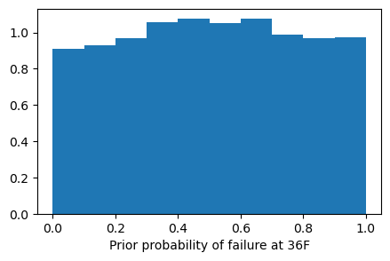

```python
plt.rcParams['figure.figsize'] = (5,3)
prior_samples = [1.0 - P_success(T=36., **prior_sample()) for i in range(5000)]
plt.hist(prior_samples, density=True); plt.xlabel('Prior probability of failure at 36F');
```

Is this distribution as expected based on the priors for the explicit model parameters? Any surprises?

## 2. Complete data

### 2a. Solution

First, let's see what the solution looks like when there are no missing data. Complete the likelihood function appropriate for a complete data set below.

```python
def ln_like_complete(success_temps, failure_temps, T0, beta, Pcold, Phot):
    """
    Return the log-likelihood corresponding to a complete data set
    `failure_temps' and `success_temps' are arrays
    All other arguments and the return value are scalars
    """
    # YOUR CODE HERE
    raise NotImplementedError()
```

```python
# test of the likelihood
# Tests like_compl_test (1 point)
```

You are now on your own to sample the posterior of the complete model. We will not prescribe a specific method or package, but for uniformity of grading there are a few requirements.

#### Requirements:

- Produce equally weighted samples from the posterior and store them (after removing any burn-in and doing any thinning you feel necessary) in `chains_complete` in the form of multiple (**at least 4**) chains, as either a list of $N_\mathrm{samples} \times N_\mathrm{params}$ arrays, or a single $N_\mathrm{chains} \times N_\mathrm{samples} \times N_\mathrm{params}$ array (i.e., in one of the formats that `incredible` understands). This doesn't mean you necessarily have to use an MCMC method, but if you use some other method you must be able to extract results in the above format (even if it means artificially breaking samples into multiple "chains"). There will be cells below for plotting traces, and tests for convergence and a minimum number of effectively independent samples, that will assume this format, and that must be passed. Parameters should be ordered as in `param_names`.
- "Approximate Methods" methods are not allowed. We want the real posterior.
- **Explain your work** with the kind of verbosity you're accustomed to seeing in these notebooks. Leave in any work that was part of your process (e.g., performing an initial optimization, plotting traces before removing burn-in), even if they aren't strictly necessary for the final product.

You can use and/or add as many cells as needed below. Since you'll be doing more than 1 inference in this notebook, we really suggest you package up as much code as possible in functions/classes to make it reusable. In this case, your function/class might take the prior and likelihood functions as inputs, since you've already written them for this case and the likelihood function will be what changes later on.

```python
# YOUR CODE HERE
raise NotImplementedError()
```

```
CPU times: user 2.99 s, sys: 6.02 ms, total: 3 s
Wall time: 3 s
```

### 2b. Testing the complete fit

Welcome back! We will now look at standard diagnostics of the chains you stored in `chains_complete`. First, traces.

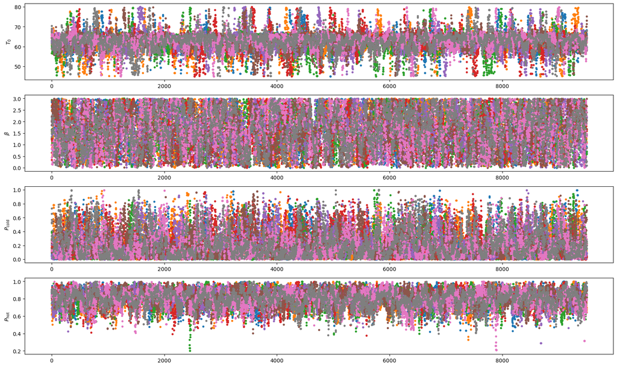

```python
# Checkpoint traces1_byI 0
fig, ax = plt.subplots(len(param_names), 1, figsize=(20, len(param_names)*3));
if chains_complete.__class__ == list:
    cr.plot_traces(chains_complete[:min(8,len(chains_complete))], ax, labels=param_labels);
else:
    cr.plot_traces(chains_complete[:min(8,chains_complete.shape[0]),:,:], ax, labels=param_labels);
# End checkpoint
```

Next the Gelman-Rubin convergence criterion and effective number of samples. Adjust the value of `maxlag` below if needed. Note that the test thresholds below are somewhat arbitrary, but fine for practice.

```python
maxlag = 1000 # you might need to change this
```

```python
# Checkpoint converge1 1
R = cr.GelmanRubinR(chains_complete)
print("R =", R)
assert np.all(R < 1.05)
neff = cr.effective_samples(chains_complete, maxlag=maxlag, throw=True)
print("neff =", neff)
assert np.all(neff > 500)
# End checkpoint
```

```
R = [1.00158446 1.00212765 1.00304753 1.00155877]
```

```
neff = [1391.01912928 1484.50035529 1071.88793283 1578.3028551 ]
```

Assuming these tests were passed, we'll combine the chains and look at a triangle.

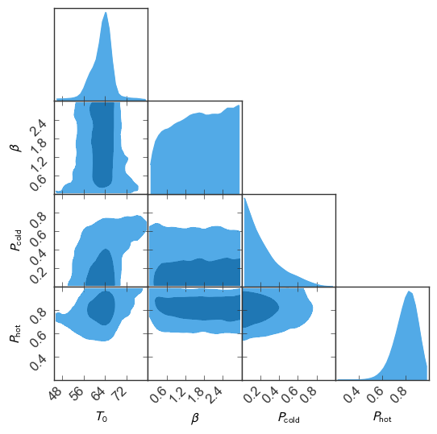

```python
# Checkpoint triangle1_byI 0
chains_complete = np.concatenate(chains_complete, axis=0)
plotGTC(chains_complete, paramNames=param_labels, figureSize=6, customLabelFont={'size':12}, customTickFont={'size':12});
# End checkpoint
```

There's a good chance that the chains and posterior look considerably uglier than you're used to in this course. (See comments in earlier notes about the difference between convergence and having tight constraints.) Again, this is a situation where we are less concerned with constraints on individual parameters than with predictions for the predicted failure probability as a function of temperature. So let's visualize that using the given function below.

```python
def post_prediction_plots(chains, labels, temperatures=np.arange(30., 85.), probs=[0.5, 0.16, 0.84], temp1=36.0, temp2=72.0):
    plt.rcParams['figure.figsize'] = (12., 4.)
    fig, ax = plt.subplots(1, 2);
    for i,chain in enumerate(chains):
        Pfail = np.array([1.0-P_success(T, *chain.T) for T in temperatures])
        color = 'C'+str(i)
        label = labels[i]
        p = np.quantile(Pfail, probs[0], axis=1)
        ax[0].plot(temperatures, p, color+'-', label=label)
        for prob in probs[1:]:
            p = np.quantile(Pfail, prob, axis=1)
            ax[0].plot(temperatures, p, color+'--')
        whist = cr.whist(1.0-P_success(temp1, *chain.T))
        ax[1].plot(whist['x'], whist['density'], color+'-');
        whist = cr.whist(1.0-P_success(temp2, *chain.T))
        ax[1].plot(whist['x'], whist['density'], color+'--');
    ax[0].set_xlabel('T (F)');
    ax[0].set_ylabel(r'$P_\mathrm{failure}(T)$');
    ax[0].set_ylim(0, 1);
    ax[0].legend();
    ax[1].set_xlabel(r'$P_\mathrm{failure}(T='+str(temp1)+'$ or $'+str(temp2)+'$ F$)$');
    ax[1].set_ylabel('posterior density');
```

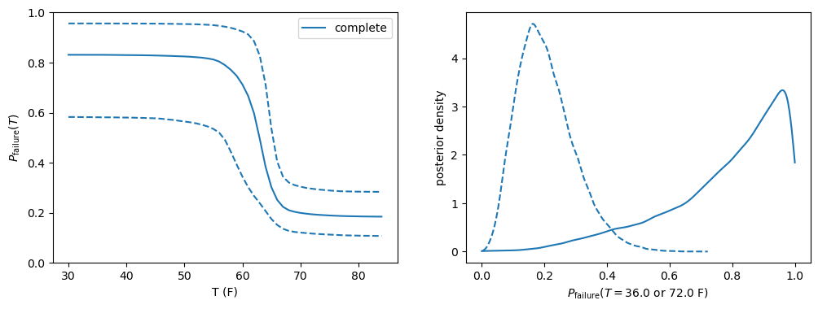

```python
post_prediction_plots([chains_complete], ['complete'])
```

Here the solid and dashed lines (left) show the posterior-predictive median and and percentile-based 68% credible interval for $P_\mathrm{failure} = 1 - P_\mathrm{success}$ at each temperature. The right panel shows the posterior for $P_\mathrm{failure}$ at a temperature of 36 F specifically as a solid curve. Note that this is a case where the median and mode of the posterior are quite different. The posterior for $P_\mathrm{failure}(T=72\,\mathrm{F})$ is shown as a dashed curve, since one could argue that the key question is not how likely failure is on a cold day, but how much more likely it is than under more typical conditions.

```python
# crude test of the posterior
# Tests post_compl_test (1 point)
```

## 3. Censored success temperatures

Imagine we are in a slightly better situation than that shown in the top panel of Figure 6 from the report. Namely, we are given

1. the temperatures of launches where there were O-ring failures (`failure_temps` above),
2. the number of launches with no failures,
3. a range of temperatures containing the successful launches (we'll assume uniform priors on each temperature), but **not** the precise values of each.

For (3), we'll discuss the exact limits to use in class, but a reasonable basis for the lower bound is the vague statement that none of the successful launches were in especially cold weather (unless you want to hide that from yourself also!). The range of the failure temperatures is also potentially relevant. Note that the results are quite sensitive to these bounds, so what you end up with may not resemble the solutions.

```python
# success_Tmin = ...
# success_Tmax = ...

# YOUR CODE HERE
raise NotImplementedError()
```

We will also discard `success_temps` entirely, to remove any temptation.

```python
# Checkpoint del_Tsuccess
Nsuccess = len(success_temps)
del success_temps
# End checkpoint
```

### 3a. Censored model definition

Adjust your PGM and expression for the likelihood to reflect our ignorance of the temperatures of successful launches. Since they are now unknown and not dictated by anything in our previous model, the success temperatures will need a prior distribution, which we will take to be uniform over the range `[success_Tmin, success_Tmax]`.

> Space for your censored PGM, etc.

We will need to marginalize over the parameters corresponding with the success temperatures, since they are no longer fixed data. We *could* do so by MCMC sampling them, but in this case direct integration is far simpler. To be explicit, if $\theta$ abbreviates the 4 model parameters we had previously and $\phi$ stands for all the success temperatures, this marginalization looks like

$p(\theta|\mathrm{data}) = \int d\phi \, p(\theta,\phi|\mathrm{data}) \propto p(\theta) \int d\phi \, p(\phi) \, p(\mathrm{data}|\theta,\phi) \equiv p(\theta) \, p(\mathrm{data}|\theta)$.

As the last equivalence indicates, the integral of the sampling distribution, $p(\mathrm{data}|\theta,\phi)$, over the prior for the success temperatures will function as our *marginalized* likelihood.

One reason for marginalizing this way is simply that it avoids having to sample a bunch of new nuisance parameters. Another is that, for our particular definition of $P_\mathrm{success}$ and a uniform prior $p(\phi)$, the integral is analytic ([see Wikipedia](https://en.wikipedia.org/wiki/Logistic_function)). We'll take advantage of this when implementing the marginalized likelihood function below. First, complete a function to evaluate the relevant integral for a single successful launch (whose value is the same for all succesful launches, since nothing in the data distinguishes them from one another):

$\int dT \, p(T) \, P_\mathrm{success}(T|T_0, \beta, P_\mathrm{cold}, P_\mathrm{hot})$.

```python
def censoring_integral(start, end, T0, beta, Pcold, Phot):
    # start, end provide the limits of integration
    # Remaining arguments are our usual model parameters
    # Assume all arguments are scalar and return a scalar
    # YOUR CODE HERE
    raise NotImplementedError()
```

```python
# test of the integral function
# Tests test_integ (1 point)
```

With that done, complete the likelihood function for this case.

```python
def ln_like_censored(success_Tmin, success_Tmax, Nsuccess, failure_temps, T0, beta, Pcold, Phot):
    """
    Return the log-likelihood for the case of censored success temperatures
    `failure_temps' is an array
    All other arguments and the return value are scalars
    """
    # YOUR CODE HERE
    raise NotImplementedError()
```

```python
# test of the censored likelihood
# Tests like_cens_test (1 point)
```

### 3b. Censored model fit

Perform the inference for the censored model. All the same requirements apply as in the last section. Store your posterior chains in `chains_censored`.

```python
# YOUR CODE HERE
raise NotImplementedError()
```

```
CPU times: user 1.99 s, sys: 4.91 ms, total: 2 s
Wall time: 2 s
```

### 3b. Testing the censored fit

Welcome back! We will now look at standard diagnostics of the chains you stored in `chains_censored`. First, traces.

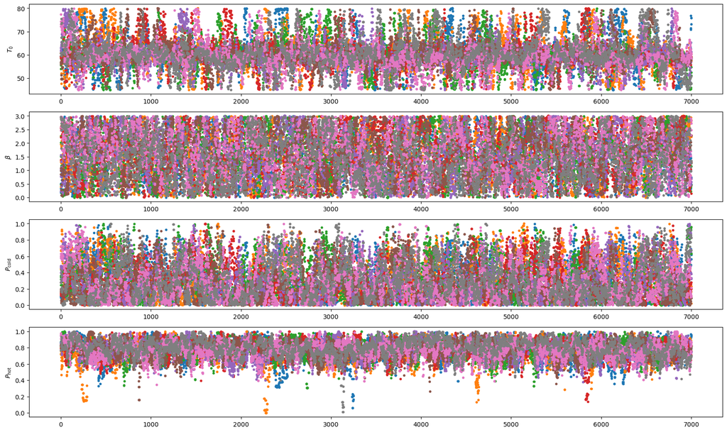

```python
# Checkpoint traces2_byI 0
fig, ax = plt.subplots(len(param_names), 1, figsize=(20, len(param_names)*3));
if chains_censored.__class__ == list:
    cr.plot_traces(chains_censored[:min(8,len(chains_complete))], ax, labels=param_labels);
else:
    cr.plot_traces(chains_censored[:min(8,chains_complete.shape[0]),:,:], ax, labels=param_labels);
# End checkpoint
```

Next the Gelman-Rubin convergence criterion and effective number of samples. Adjust the value of `maxlag` below if needed. Note that the test thresholds below are somewhat arbitrary, but fine for practice.

```python
maxlag = 1500 # you might need to change this
```

```python
# Checkpoint converge2 1
R = cr.GelmanRubinR(chains_censored)
print("R =", R)
assert np.all(R < 1.05)
neff = cr.effective_samples(chains_censored, maxlag=maxlag, throw=True)
print("neff =", neff)
assert np.all(neff > 500)
# End checkpoint
```

```
R = [1.00421525 1.00531384 1.00417726 1.00618423]
```

```
neff = [ 965.9027627  1141.06494642  790.09031264  974.106622  ]
```

Assuming these tests were passed, we'll combine the chains and look at a triangle.

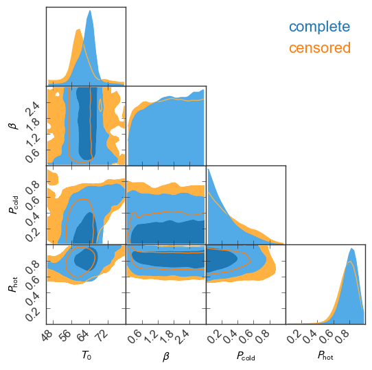

```python
# Checkpoint triangle2_byI 0
chains_censored = np.concatenate(chains_censored, axis=0)
plotGTC([chains_complete, chains_censored], chainLabels=['complete', 'censored'],
        paramNames=param_labels, figureSize=6, customLabelFont={'size':12}, customTickFont={'size':12}, customLegendFont={'size':16});
# End checkpoint
```

Finally, the posterior predictions:

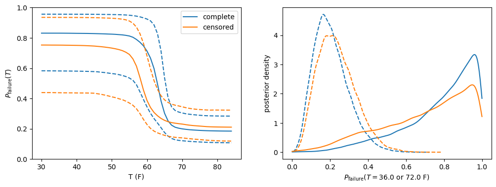

```python
post_prediction_plots([chains_complete, chains_censored], ['complete', 'censored'])
```

```python
# crude test of the posterior
# Tests post_cens_test (1 point)
```

## 4. Truncated success temperatures

We will now approach the situation shown in the top panel of Figure 6 from the report more closely, by throwing away our knowledge of the precise number of successful launches. Note that we are still retaining our presumed prior knowledge of the corresponding range of temperatures, encoded in `success_Tmin` and `success_Tmax`.

```python
# Checkpoint del_Nsuccess
del Nsuccess
# End checkpoint
```

### 4a. Truncated model definition

Like the individual success temperatures, the number of successful launches will now be a free parameter that we need to marginalize over.

Again, we will discuss what prior on $N_\mathrm{success}$ we'll use in class, and the particular results you see are fairly sensitive to this choice. (Poisson makes the marginalization below analytic, but is arguably tough to justify; in general, any prior with finite bounds is fairly straightforward to deal with here.)

Adjust your PGM and expression for the likelihood to reflect these changes.

> Space for your truncated PGM, etc.

As with the temperatures, you *could* sample $N_\mathrm{success}$ along with the other model parameters, but it will be more straightforward if we instead perform the marginalization over $N_\mathrm{success}$ within the likelihood. Do this below:

```python
def ln_like_truncated(success_Tmin, success_Tmax, failure_temps, T0, beta, Pcold, Phot):
    """
    Return the log-likelihood for the case of truncated success temperatures
    `failure_temps' is an array
    All other arguments and the return value are scalars
    """
    # YOUR CODE HERE
    raise NotImplementedError()
```

```python
# test of the truncated likelihood
# Tests like_trunc_test (1 point)
```

### 4b. Truncated model fit

Perform the inference for the trunctated model. All the same requirements apply as in the previous section. Store your posterior chains in `chains_truncated`.

```python
# YOUR CODE HERE
raise NotImplementedError()
```

```
CPU times: user 2.2 s, sys: 6.52 ms, total: 2.21 s
Wall time: 2.2 s
```

### 4b. Testing the truncated fit

Welcome back! We will now look at standard diagnostics of the chains you stored in `chains_truncated`. First, traces.

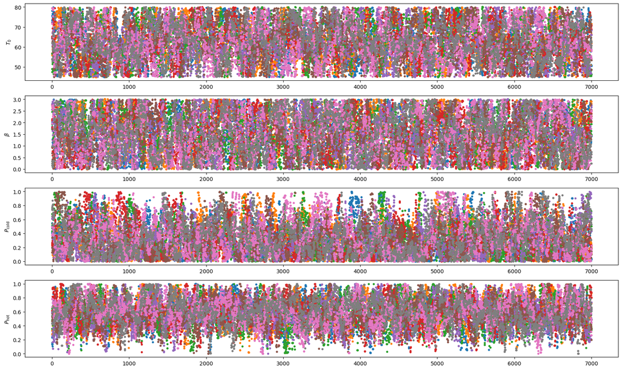

```python
# Checkpoint traces3_byI 0
fig, ax = plt.subplots(len(param_names), 1, figsize=(20, len(param_names)*3));
if chains_truncated.__class__ == list:
    cr.plot_traces(chains_truncated[:min(8,len(chains_truncated))], ax, labels=param_labels);
else:
    cr.plot_traces(chains_truncated[:min(8,chains_truncated.shape[0]),:,:], ax, labels=param_labels);
# End checkpoint
```

Next the Gelman-Rubin convergence criterion and effective number of samples. Adjust the value of `maxlag` below if needed. Note that the test thresholds below are somewhat arbitrary, but fine for practice.

```python
maxlag = 1000 # you might need to change this
```

```python
# Checkpoint converge3 1
R = cr.GelmanRubinR(chains_truncated)
print("R =", R)
assert np.all(R < 1.05)
neff = cr.effective_samples(chains_truncated, maxlag=maxlag, throw=True)
print("neff =", neff)
assert np.all(neff > 500)
# End checkpoint
```

```
R = [1.00141796 1.00148657 1.00294025 1.00242062]
```

```
neff = [ 985.99423464  908.29086866  675.27493051 1011.76544376]
```

Assuming these tests were passed, we'll combine the chains and look at a triangle.

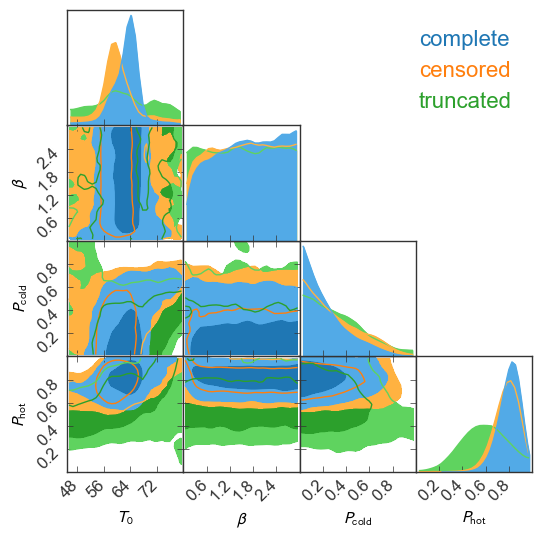

```python
# Checkpoint triangle3_byI 0
chains_truncated = np.concatenate(chains_truncated, axis=0)
plotGTC([chains_complete, chains_censored, chains_truncated], chainLabels=['complete', 'censored', 'truncated'],
        paramNames=param_labels, figureSize=6, customLabelFont={'size':12}, customTickFont={'size':12}, customLegendFont={'size':16});
# End checkpoint
```

Finally, the posterior predictions:

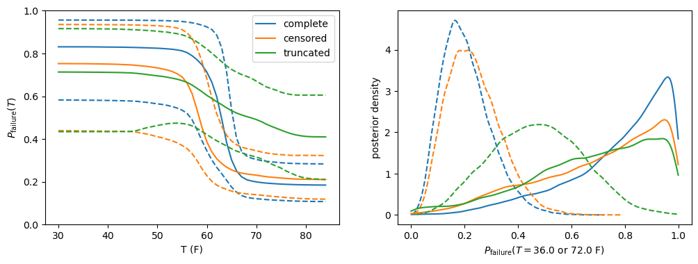

```python
post_prediction_plots([chains_complete, chains_censored, chains_truncated], ['complete', 'censored', 'truncated'])
```

```python
# crude test of the posterior
# Tests post_trunc_test (1 point)
```

## Parting thoughts

We approached this problem backwards in a sense, knowing the answer provided by the complete data set, and progressively hiding information to see how the conclusions changed, or don't. For each inference above, it's worth pausing and thinking about the following questions:

- Do the posterior predictions make sense compared with inspection of the data (with or without the missing pieces) and the prior?
- Is the report's conclusion that "the probability of O-ring distress is increased to almost a certainty if the temperature of the joint is less than 65" fair in this scenario?

As noted above, the answers to those questions are rather sensitive to the priors we adopt in the censored/truncated cases. Remember that these represent the additional information available to, or at least in the minds of, decision makers faced with the first plot in the figure from the report. The results could thus include extreme conclusions like "every single launch as had a failure!" (truncated model allowing for $N_\mathrm{success}=0$, i.e. the most literal interpretation of the original figure). However, with a realistic amount of additional information (e.g. that every successful launch occured in warm weather), it's hard to avoid the conclusion that O-ring failure probability increases significantly at lower temperatures. In any case, it's enlightening to see how the conclusions change as the prior information is adjusted, and you're encouraged to investigate which aspects of the priors are most important for concluding (or not) that temperature has an important impact on the probability of O-ring failure.

```python
# moar housekeeping
# Tests housekeeping2
```